# Homework - features and elements of multiple regression

# 1 MVP

1. Load the `diamonds.csv` data set and undertake an initial exploration of the data. You will find a description of the meanings of the variables on the relevant [Kaggle page](https://www.kaggle.com/shivam2503/diamonds/)

```r
diamonds <- read_csv("diamonds.csv")
library(GGally)
library(tidyverse)
glimpse(diamonds)
```

```
## Rows: 53,940
## Columns: 11
## $ X1      <dbl> 1, 2, 3, 4, 5, 6, 7, 8, 9, 10, 11, 12, 13, 14, 15, 16, 17, 18…
## $ carat   <dbl> 0.23, 0.21, 0.23, 0.29, 0.31, 0.24, 0.24, 0.26, 0.22, 0.23, 0…
## $ cut     <chr> "Ideal", "Premium", "Good", "Premium", "Good", "Very Good", "…
## $ color   <chr> "E", "E", "E", "I", "J", "J", "I", "H", "E", "H", "J", "J", "…
## $ clarity <chr> "SI2", "SI1", "VS1", "VS2", "SI2", "VVS2", "VVS1", "SI1", "VS…
## $ depth   <dbl> 61.5, 59.8, 56.9, 62.4, 63.3, 62.8, 62.3, 61.9, 65.1, 59.4, 6…
## $ table   <dbl> 55, 61, 65, 58, 58, 57, 57, 55, 61, 61, 55, 56, 61, 54, 62, 5…
## $ price   <dbl> 326, 326, 327, 334, 335, 336, 336, 337, 337, 338, 339, 340, 3…
## $ x       <dbl> 3.95, 3.89, 4.05, 4.20, 4.34, 3.94, 3.95, 4.07, 3.87, 4.00, 4…
## $ y       <dbl> 3.98, 3.84, 4.07, 4.23, 4.35, 3.96, 3.98, 4.11, 3.78, 4.05, 4…
## $ z       <dbl> 2.43, 2.31, 2.31, 2.63, 2.75, 2.48, 2.47, 2.53, 2.49, 2.39, 2…
```

2. We expect the `carat` of the diamonds to be strong correlated with the physical dimensions `x`, `y` and `z`. Use `ggpairs()` to investigate correlations between these four variables.

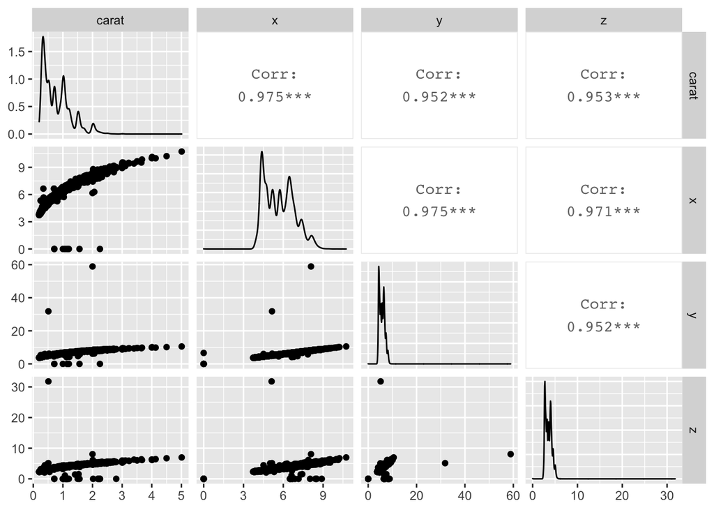

```r
ggpairs(diamonds[,c("carat", "x", "y", "z")])
```

3. So, we do find significant correlations. Let’s drop columns `x`, `y` and `z` from the dataset, in preparation to use only `carat` going forward.

```r
diamonds_tidy <- diamonds %>%
  select(-c("x", "y", "z"))

diamonds_tidy
```

| X1 | carat | cut | color | clarity | depth | table | price |
| --- | --- | --- | --- | --- | --- | --- | --- |
| 1 | 0.23 | Ideal | E | SI2 | 61.5 | 55.0 | 326 |
| 2 | 0.21 | Premium | E | SI1 | 59.8 | 61.0 | 326 |
| 3 | 0.23 | Good | E | VS1 | 56.9 | 65.0 | 327 |
| 4 | 0.29 | Premium | I | VS2 | 62.4 | 58.0 | 334 |
| 5 | 0.31 | Good | J | SI2 | 63.3 | 58.0 | 335 |
| 6 | 0.24 | Very Good | J | VVS2 | 62.8 | 57.0 | 336 |
| 7 | 0.24 | Very Good | I | VVS1 | 62.3 | 57.0 | 336 |
| 8 | 0.26 | Very Good | H | SI1 | 61.9 | 55.0 | 337 |
| 9 | 0.22 | Fair | E | VS2 | 65.1 | 61.0 | 337 |
| 10 | 0.23 | Very Good | H | VS1 | 59.4 | 61.0 | 338 |

[output cut: 9990 more lines]

4. We are interested in developing a regression model for the `price` of a diamond in terms of the possible predictor variables in the dataset.
1. Use `ggpairs()` to investigate correlations between `price` and the predictors (this may take a while to run, don’t worry, make coffee or something).

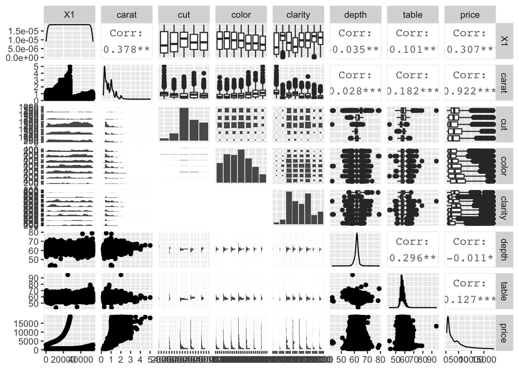

```r
ggpairs(diamonds_tidy)
```

`carat` is strongly correlated with `price`. Boxplots of `price` split by `cut`, `color` and particularly `clarity` also show some variation.

2. Perform further `ggplot` visualisations of any significant correlations you find.

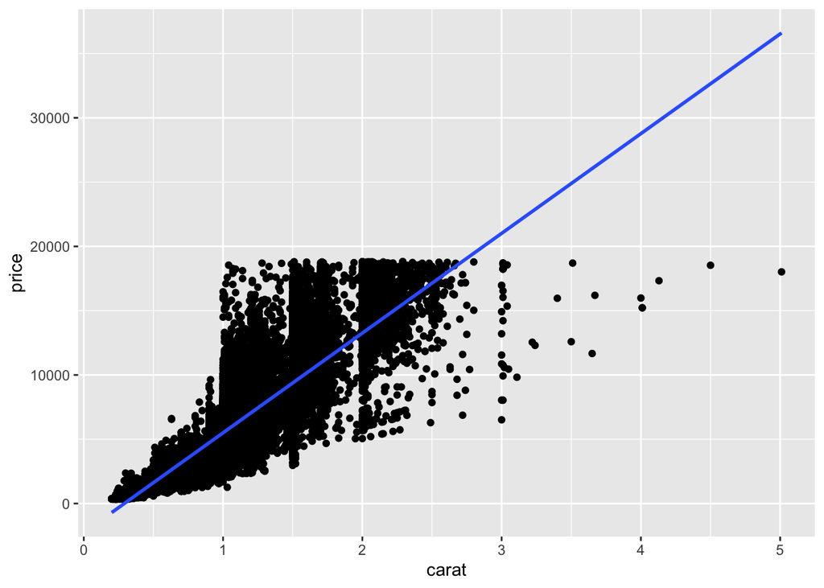

```r
diamonds_tidy %>%
  ggplot(aes(x = carat, y = price)) +
  geom_point() +
  geom_smooth(method = "lm", se = FALSE)
```

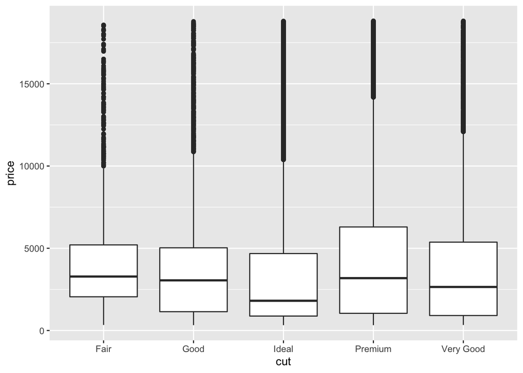

```r
diamonds_tidy %>%
  ggplot(aes(x = cut, y = price)) +
  geom_boxplot()
```

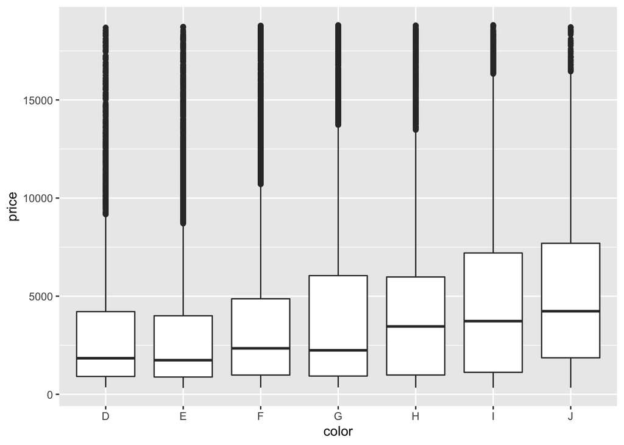

```r
diamonds_tidy %>%
  ggplot(aes(x = color, y = price)) +
  geom_boxplot()
```

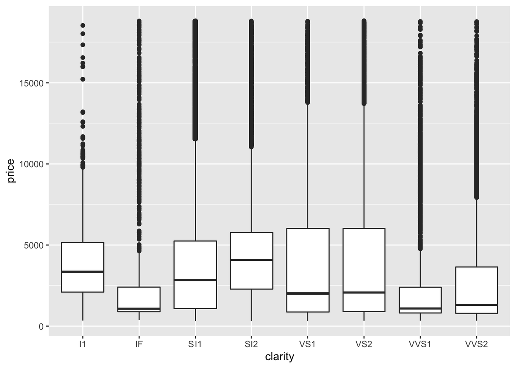

```r
diamonds_tidy %>%
  ggplot(aes(x = clarity, y = price)) +
  geom_boxplot()
```

5. Shortly we may try a regression fit using one or more of the categorical predictors `cut`, `clarity` and `color`, so let’s investigate these predictors:
1. Investigate the levels of these predictors. How many dummy variables do you expect for each of them?

```r
unique(diamonds_tidy$cut)
```

```
## [1] "Ideal"     "Premium"   "Good"      "Very Good" "Fair"
```

```r
# expect 4 dummies for cut

unique(diamonds_tidy$color)
```

```
## [1] "E" "I" "J" "H" "F" "G" "D"
```

```r
# expect 6 dummies for color

unique(diamonds_tidy$clarity)
```

```
## [1] "SI2"  "SI1"  "VS1"  "VS2"  "VVS2" "VVS1" "I1"   "IF"
```

```r
# expect 7 dummies for clarity
```

2. Use the `dummy_cols()` function in the `fastDummies` package to generate dummies for these predictors and check the number of dummies in each case.

```r
library(fastDummies)
diamonds_dummies <- dummy_cols(diamonds, select_columns = c("cut", "clarity", "color"), remove_first_dummy = TRUE)
glimpse(diamonds_dummies)
```

```
## Rows: 53,940
## Columns: 28
## $ X1              <dbl> 1, 2, 3, 4, 5, 6, 7, 8, 9, 10, 11, 12, 13, 14, 15, 16…
## $ carat           <dbl> 0.23, 0.21, 0.23, 0.29, 0.31, 0.24, 0.24, 0.26, 0.22,…
## $ cut             <chr> "Ideal", "Premium", "Good", "Premium", "Good", "Very …
## $ color           <chr> "E", "E", "E", "I", "J", "J", "I", "H", "E", "H", "J"…
## $ clarity         <chr> "SI2", "SI1", "VS1", "VS2", "SI2", "VVS2", "VVS1", "S…
## $ depth           <dbl> 61.5, 59.8, 56.9, 62.4, 63.3, 62.8, 62.3, 61.9, 65.1,…
## $ table           <dbl> 55, 61, 65, 58, 58, 57, 57, 55, 61, 61, 55, 56, 61, 5…
## $ price           <dbl> 326, 326, 327, 334, 335, 336, 336, 337, 337, 338, 339…
## $ x               <dbl> 3.95, 3.89, 4.05, 4.20, 4.34, 3.94, 3.95, 4.07, 3.87,…
## $ y               <dbl> 3.98, 3.84, 4.07, 4.23, 4.35, 3.96, 3.98, 4.11, 3.78,…
## $ z               <dbl> 2.43, 2.31, 2.31, 2.63, 2.75, 2.48, 2.47, 2.53, 2.49,…
## $ cut_Good        <int> 0, 0, 1, 0, 1, 0, 0, 0, 0, 0, 1, 0, 0, 0, 0, 0, 0, 1,…
## $ cut_Ideal       <int> 1, 0, 0, 0, 0, 0, 0, 0, 0, 0, 0, 1, 0, 1, 0, 0, 1, 0,…
## $ cut_Premium     <int> 0, 1, 0, 1, 0, 0, 0, 0, 0, 0, 0, 0, 1, 0, 1, 1, 0, 0,…
## $ `cut_Very Good` <int> 0, 0, 0, 0, 0, 1, 1, 1, 0, 1, 0, 0, 0, 0, 0, 0, 0, 0,…
## $ clarity_IF      <int> 0, 0, 0, 0, 0, 0, 0, 0, 0, 0, 0, 0, 0, 0, 0, 0, 0, 0,…
## $ clarity_SI1     <int> 0, 1, 0, 0, 0, 0, 0, 1, 0, 0, 1, 0, 1, 0, 0, 0, 0, 1,…
## $ clarity_SI2     <int> 1, 0, 0, 0, 1, 0, 0, 0, 0, 0, 0, 0, 0, 1, 1, 0, 1, 0,…
## $ clarity_VS1     <int> 0, 0, 1, 0, 0, 0, 0, 0, 0, 1, 0, 1, 0, 0, 0, 0, 0, 0,…
## $ clarity_VS2     <int> 0, 0, 0, 1, 0, 0, 0, 0, 1, 0, 0, 0, 0, 0, 0, 0, 0, 0,…
## $ clarity_VVS1    <int> 0, 0, 0, 0, 0, 0, 1, 0, 0, 0, 0, 0, 0, 0, 0, 0, 0, 0,…
## $ clarity_VVS2    <int> 0, 0, 0, 0, 0, 1, 0, 0, 0, 0, 0, 0, 0, 0, 0, 0, 0, 0,…
## $ color_E         <int> 1, 1, 1, 0, 0, 0, 0, 0, 1, 0, 0, 0, 0, 0, 1, 1, 0, 0,…
## $ color_F         <int> 0, 0, 0, 0, 0, 0, 0, 0, 0, 0, 0, 0, 1, 0, 0, 0, 0, 0,…
## $ color_G         <int> 0, 0, 0, 0, 0, 0, 0, 0, 0, 0, 0, 0, 0, 0, 0, 0, 0, 0,…
## $ color_H         <int> 0, 0, 0, 0, 0, 0, 0, 1, 0, 1, 0, 0, 0, 0, 0, 0, 0, 0,…
## $ color_I         <int> 0, 0, 0, 1, 0, 0, 1, 0, 0, 0, 0, 0, 0, 0, 0, 0, 1, 0,…
## $ color_J         <int> 0, 0, 0, 0, 1, 1, 0, 0, 0, 0, 1, 1, 0, 1, 0, 0, 0, 1,…
```

6. Going forward we’ll let `R` handle dummy variable creation for categorical predictors in regression fitting (remember `lm()` will generate the correct numbers of dummy levels automatically, absorbing one of the levels into the intercept as a reference level)
1. First, we’ll start with simple linear regression. Regress `price` on `carat` and check the regression diagnostics.

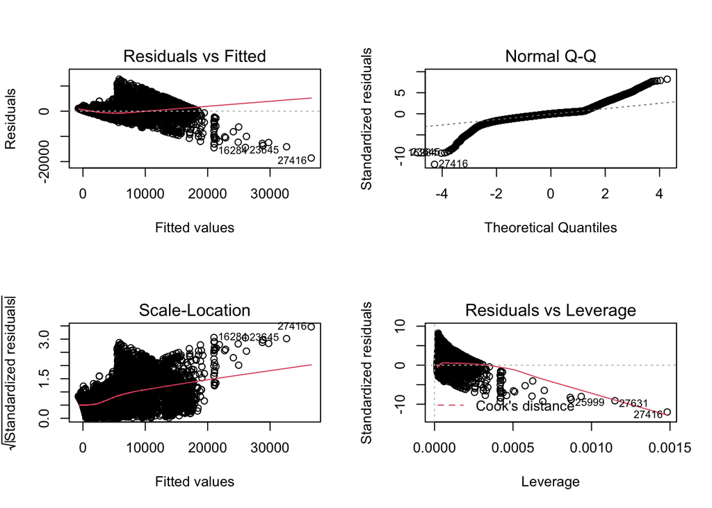

```r
mod1 <- lm(price ~ carat, data = diamonds_tidy)
par(mfrow = c(2,2))
plot(mod1)
```

```r
# the residuals show systematic variation, significant deviation from normality and heteroscedasticity. Oh dear...
```

2. Run a regression with one or both of the predictor and response variables `log()` transformed and recheck the diagnostics. Do you see any improvement?

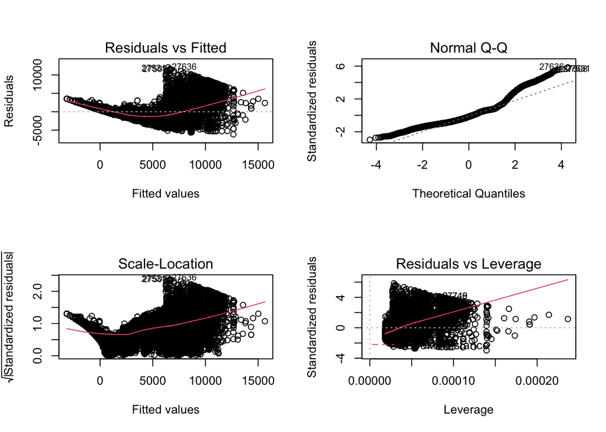

```r
mod2_logx <- lm(price ~ log(carat), data = diamonds_tidy)
par(mfrow = c(2,2))
plot(mod2_logx)
```

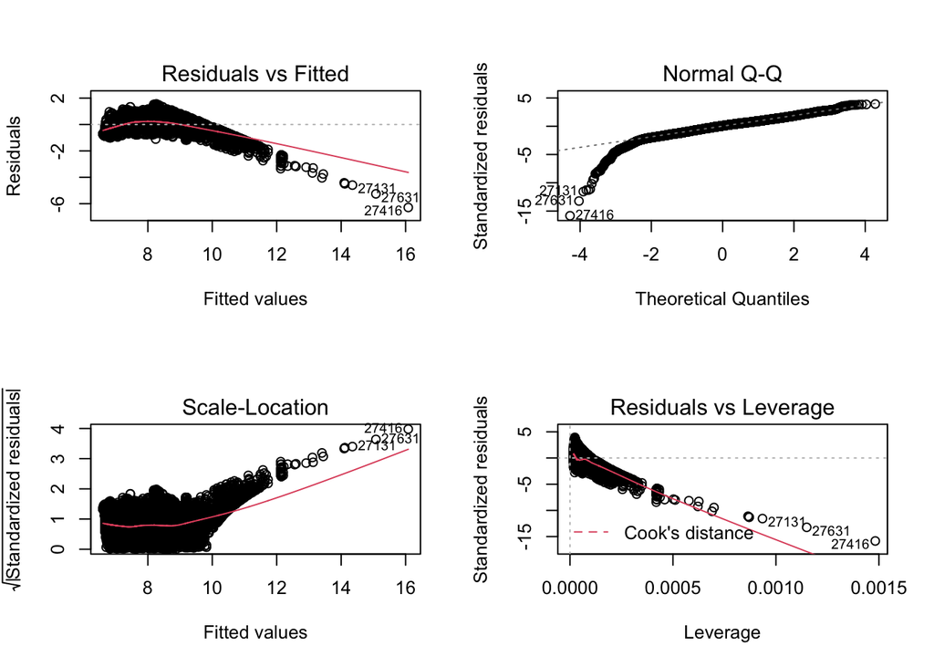

```r
mod2_logy <- lm(log(price) ~ carat, data = diamonds_tidy)
par(mfrow = c(2,2))
plot(mod2_logy)
```

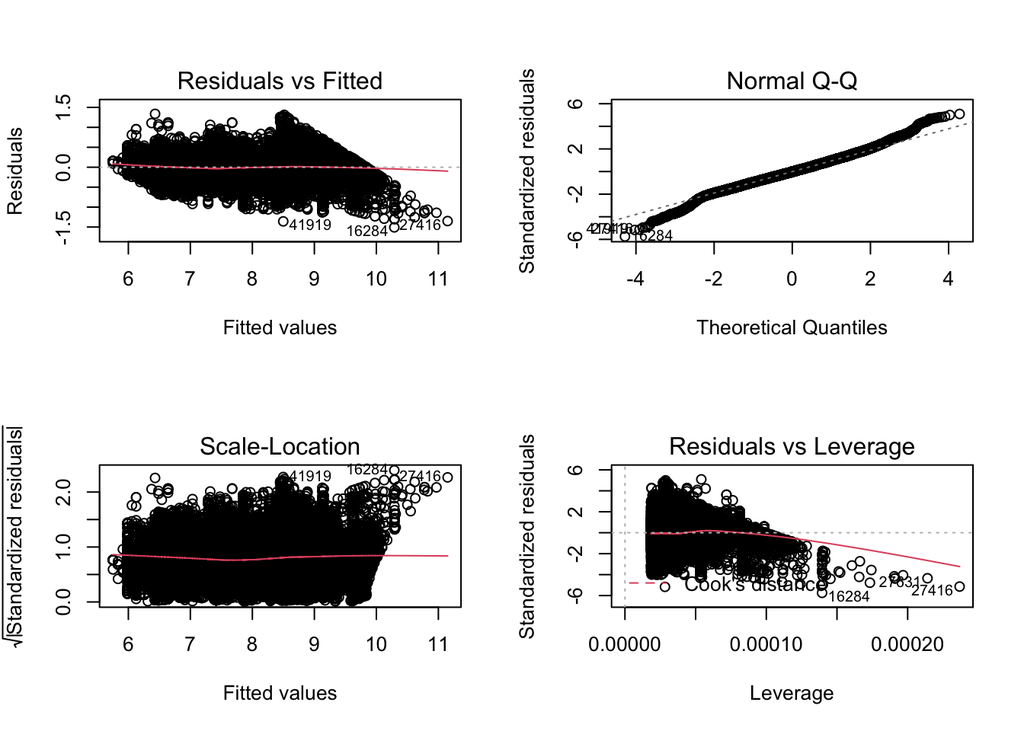

```r
mod2_logxlogy <- lm(log(price) ~ log(carat), data = diamonds_tidy)
par(mfrow = c(2,2))
plot(mod2_logxlogy)
```

```r
# it looks like log transformation of both variables is required to get close to satisfying the regression assumptions.
```

3. Let’s use `log()` transformations of both predictor and response. Next, experiment with adding **a single** categorical predictor into the model. Which categorical predictor is best? [**Hint** - investigate $r^2$ values]

```r
mod3_cut <- lm(log(price) ~ log(carat) + cut, data = diamonds_tidy)
summary(mod3_cut)
```

```
##
## Call:
## lm(formula = log(price) ~ log(carat) + cut, data = diamonds_tidy)
##
## Residuals:
##      Min       1Q   Median       3Q      Max
## -1.52247 -0.16484 -0.00587  0.16087  1.38115
##
## Coefficients:
##              Estimate Std. Error t value Pr(>|t|)
## (Intercept)  8.200125   0.006343 1292.69   <2e-16 ***
## log(carat)   1.695771   0.001910  887.68   <2e-16 ***
## cutGood      0.163245   0.007324   22.29   <2e-16 ***
## cutIdeal     0.317212   0.006632   47.83   <2e-16 ***
## cutPremium   0.238217   0.006716   35.47   <2e-16 ***
## cutVery Good 0.240753   0.006779   35.52   <2e-16 ***
## ---
## Signif. codes:  0 '***' 0.001 '**' 0.01 '*' 0.05 '.' 0.1 ' ' 1
##
## Residual standard error: 0.2545 on 53934 degrees of freedom
## Multiple R-squared:  0.9371, Adjusted R-squared:  0.9371
## F-statistic: 1.607e+05 on 5 and 53934 DF,  p-value: < 2.2e-16
```

```r
mod3_color <- lm(log(price) ~ log(carat) + color, data = diamonds_tidy)
summary(mod3_color)
```

```
##
## Call:
## lm(formula = log(price) ~ log(carat) + color, data = diamonds_tidy)
##
## Residuals:
##      Min       1Q   Median       3Q      Max
## -1.49987 -0.14888  0.00257  0.15316  1.27815
##
## Coefficients:
##              Estimate Std. Error  t value Pr(>|t|)
## (Intercept)  8.572034   0.003051 2809.531  < 2e-16 ***
## log(carat)   1.728631   0.001814  952.727  < 2e-16 ***
## colorE      -0.025460   0.003748   -6.793 1.11e-11 ***
## colorF      -0.034455   0.003773   -9.132  < 2e-16 ***
## colorG      -0.055399   0.003653  -15.166  < 2e-16 ***
## colorH      -0.189859   0.003917  -48.468  < 2e-16 ***
## colorI      -0.286928   0.004383  -65.467  < 2e-16 ***
## colorJ      -0.425038   0.005417  -78.466  < 2e-16 ***
## ---
## Signif. codes:  0 '***' 0.001 '**' 0.01 '*' 0.05 '.' 0.1 ' ' 1
##
## Residual standard error: 0.2372 on 53932 degrees of freedom
## Multiple R-squared:  0.9454, Adjusted R-squared:  0.9454
## F-statistic: 1.333e+05 on 7 and 53932 DF,  p-value: < 2.2e-16
```

```r
mod3_clarity <- lm(log(price) ~ log(carat) + clarity, data = diamonds_tidy)
summary(mod3_clarity)
```

```
##
## Call:
## lm(formula = log(price) ~ log(carat) + clarity, data = diamonds_tidy)
##
## Residuals:
##      Min       1Q   Median       3Q      Max
## -0.97521 -0.12085  0.01048  0.12561  1.85854
##
## Coefficients:
##             Estimate Std. Error t value Pr(>|t|)
## (Intercept) 7.768115   0.006940 1119.25   <2e-16 ***
## log(carat)  1.806424   0.001514 1193.23   <2e-16 ***
## clarityIF   1.114625   0.008376  133.07   <2e-16 ***
## claritySI1  0.624558   0.007163   87.19   <2e-16 ***
## claritySI2  0.479658   0.007217   66.46   <2e-16 ***
## clarityVS1  0.820461   0.007306  112.30   <2e-16 ***
## clarityVS2  0.775248   0.007197  107.72   <2e-16 ***
## clarityVVS1 1.028298   0.007745  132.77   <2e-16 ***
## clarityVVS2 0.979221   0.007529  130.05   <2e-16 ***
## ---
## Signif. codes:  0 '***' 0.001 '**' 0.01 '*' 0.05 '.' 0.1 ' ' 1
##
## Residual standard error: 0.1888 on 53931 degrees of freedom
## Multiple R-squared:  0.9654, Adjusted R-squared:  0.9654
## F-statistic: 1.879e+05 on 8 and 53931 DF,  p-value: < 2.2e-16
```

```r
# clarity leads to a model with highest r^2, all predictors are significant
```

4. [**Try this question if you have looked at the material on transformations**] Interpret the fitted coefficients for the levels of your chosen categorical predictor. Which level is the reference level? Which level shows the greatest difference in price from the reference level? [**Hints** - remember we are regressing the `log(price)` here, and think about what the presence of the `log(carat)` predictor implies. We’re not expecting a mathematical explanation]

```r
# 'I1' is the reference level for clarity. In multiple linear regression, the interpretation of any
# coefficient is the change in response due to that predictor with other predictors held constant
# log(price) makes the relationship geometric. Clarity = 'IF' shows the most difference from the reference level.

# Here's how to interpret the `clarityIF` coefficient in the presence of the `log(price)` response

ratio <- exp(1.114625)
ratio
```

```
## [1] 3.048425
```

```r
# so, on average, the price of an IF diamond will be approx. 3 times higher than that of I1 diamond of same carat.
```

# 2 Extension

7. Try adding an interaction between `log(carat)` and your chosen categorical predictor. Do you think this interaction term is statistically justified?

```r
mod4_clarity_inter <- lm(log(price) ~ log(carat) + clarity + log(carat):clarity, data = diamonds_tidy)
summary(mod4_clarity_inter)
```

```
##
## Call:
## lm(formula = log(price) ~ log(carat) + clarity + log(carat):clarity,
##     data = diamonds_tidy)
##
## Residuals:
##      Min       1Q   Median       3Q      Max
## -0.92773 -0.12104  0.01212  0.12465  1.51830
##
## Coefficients:
##                        Estimate Std. Error t value Pr(>|t|)
## (Intercept)            7.808102   0.007223 1080.98   <2e-16 ***
## log(carat)             1.528106   0.014944  102.25   <2e-16 ***
## clarityIF              1.122732   0.011381   98.65   <2e-16 ***
## claritySI1             0.587556   0.007465   78.71   <2e-16 ***
## claritySI2             0.438797   0.007486   58.62   <2e-16 ***
## clarityVS1             0.790989   0.007721  102.45   <2e-16 ***
## clarityVS2             0.723109   0.007530   96.03   <2e-16 ***
## clarityVVS1            1.007591   0.009506  106.00   <2e-16 ***
## clarityVVS2            0.968426   0.008359  115.85   <2e-16 ***
## log(carat):clarityIF   0.337116   0.017593   19.16   <2e-16 ***
## log(carat):claritySI1  0.288214   0.015254   18.89   <2e-16 ***
## log(carat):claritySI2  0.258795   0.015437   16.76   <2e-16 ***
## log(carat):clarityVS1  0.300307   0.015395   19.51   <2e-16 ***
## log(carat):clarityVS2  0.250187   0.015237   16.42   <2e-16 ***
## log(carat):clarityVVS1 0.301955   0.016317   18.51   <2e-16 ***
## log(carat):clarityVVS2 0.321665   0.015717   20.47   <2e-16 ***
## ---
## Signif. codes:  0 '***' 0.001 '**' 0.01 '*' 0.05 '.' 0.1 ' ' 1
##
## Residual standard error: 0.1877 on 53924 degrees of freedom
## Multiple R-squared:  0.9658, Adjusted R-squared:  0.9658
## F-statistic: 1.014e+05 on 15 and 53924 DF,  p-value: < 2.2e-16
```

```r
# obtain only a small improvement in r^2 from the interaction.
# we'll see shortly that the correct test would be an anova() comparing both models
anova(mod3_clarity, mod4_clarity_inter)
```

|  | Res.Df | RSS | Df | Sum of Sq | F | Pr(>F) |
| --- | --- | --- | --- | --- | --- | --- |
| 1 | 53931 | 1923.125 | NA | NA | NA | NA |
| 2 | 53924 | 1900.567 | 7 | 22.55812 | 91.43317 | 3.707725e-133 |

```r
# the small p-value suggests interaction is statistically significant, but the effect is small.
```

8. Find and plot an appropriate visualisation to show the effect of this interaction

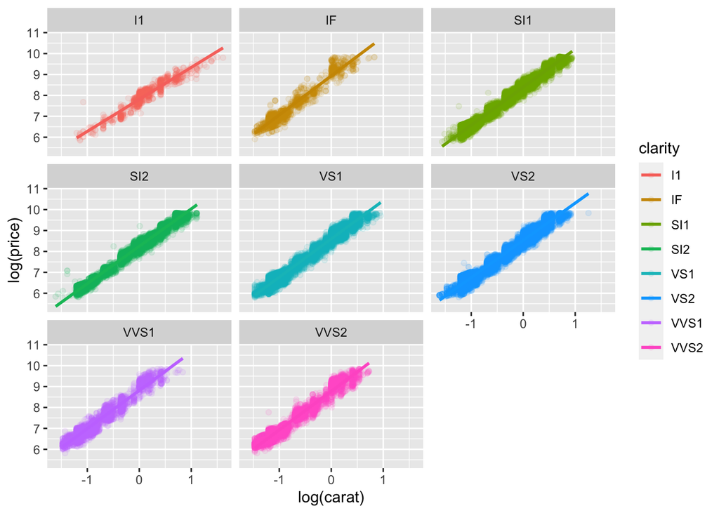

```r
diamonds_tidy %>%
  ggplot(aes(x = log(carat), y = log(price), colour = clarity)) +
  geom_point(alpha = 0.1) +
  geom_smooth(method = "lm", se = FALSE) +
  facet_wrap(~ clarity)
```

```r
# not much evidence that the gradient of the line varies significantly with clarity
```